# 1.

### 1.1. is model selection and model assessment the same?

--> No

- **Model selection**: estimating the performance of different models in order to choose the best one.
- **Model assessment**: having chosen a final model, estimating its prediction error (generalization error) on new data.

A standard modeling workflow would see you partitioning your data into the training, validation, and testing sets. You would fit your models to the training data, then use the validation set to perform **model selection**, and finally, evaluate the very best selected model on the test data to see what generalization performance can be expected of it (**model assessment**)

### 1.2.

**Generalization** refers to a model’s ability to adapt and react appropriately to previously unseen, fresh data chosen from the same distribution as the model’s initial input. In other words, generalization assesses a model’s ability to process new data and generate accurate predictions after being trained on a training set.

In most scenarios, we generally focused on the training set or tried to optimize the performance on the training set. But this is not the correct way of model building, there is a lot of uncertainty (such as noise) in the unseen data which is taken from the same distribution as the training set. So in such cases, we also should aim for our model that can generalize well on those unseen data.

Fortunately, there is a simple method for assessing a model’s generalization performance. Simply put, we divide our data into three subsets.

A training set is a collection of training examples on which the network is trained. A validation set is used to fine-tune hyperparameters like the number of hidden units and the learning rate. A test set designed to evaluate generalization performance. The losses on these subsets are referred to as training, validation, and test loss, in that order. It should be evident why we need distinct training and test sets: if we train on test data, we have no notion if the model is correctly generalizing or merely memorizing the training examples.

As we can see in the below image, the validation set helps us to reach maximum generalization performance.

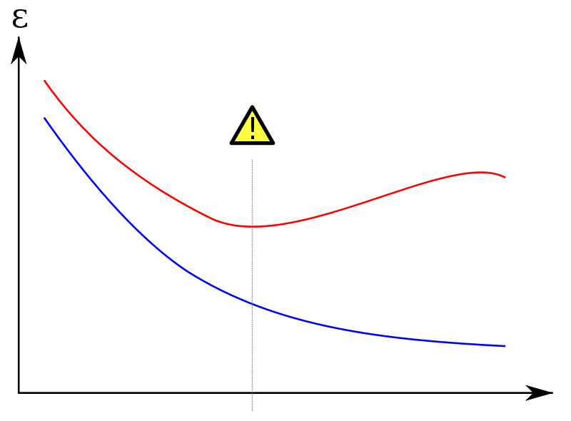

### 1.3

When we deal with a small dataset, we can use the cross-validation method to assess the model. It's important to mention that choosing K can be tricky in this case because a smaller K leads the model to overfit. For example, if the dataset has 100 samples, we can't use 3-fold or 5-fold cross-validation.

### 1.4. Model Metrics

- Classification Metrics:
  1. Confusion Matrix
  2. Area Under the ROC curve (AUC – ROC)

     AUC stands for "Area under the ROC Curve." That is, AUC measures the entire two-dimensional area underneath the entire ROC curve. AUC provides an aggregate measure of performance across all possible classification thresholds. One way of interpreting AUC is as the probability that the model ranks a random positive example more highly than a random negative example.
- Regression Metrics:
  1. Mean Squared Error (MSE)
  2. Root Mean Squared Error (RMSE).
  3. Mean Absolute Error (MAE)

# 2

### 2.1 objective of feature selection

The objective of feature selection is to remove irrelevant and/or redundant features and retain only relevant features. Irrelevant features can be removed without affecting learning performance.

benefits of feature selection :

- Reduces Overfitting: Less redundant data means less opportunity to make decisions based on noise.
- Improves Accuracy: Less misleading data means modeling accuracy improves.
- Reduces Training Time: Less data means that algorithms train faster.

### 2- Fisher score for feature selection

Fisher Score is a **supervised** linear feature extraction method. For each feature/variable, it computes Fisher score, a ratio of between-class variance to within-class variance. The algorithm selects variables with largest Fisher scores and returns an indicator projection matrix. It is solved by cutting plane algorithm, in each iteration of which a multiple kernel learning problem is solved alternatively by multivariate ridge regression and projected gradient descent.

the Fisher score algorithm selects each feature independently in accordance with their scores. Here, Feature selection using the Fisher score algorithm results in a list of genes that are ranked by their importance.

# 6

### 6.1. Non-distance based clustering

There are plenty of grid-based clustering approaches. They don't compute distances because that would often yield quadratic runtime. Instead, they partition the data and aggregate it into grid cells. But the intuition behind such approaches is usually very closely related to distances.

There are clustering approaches for graphs. But either they reduce to classic graph problems such as clique or near-clique finding and graph coloring, or they are closely connected to distance-based clustering (if you have a weighted graph).

Density-based clustering like DBSCAN has a different name, and isn't focused around minimizing distances; but "density" is usually specified with respect to a distance, so technically these algorithms are either distance-based or grid-based.

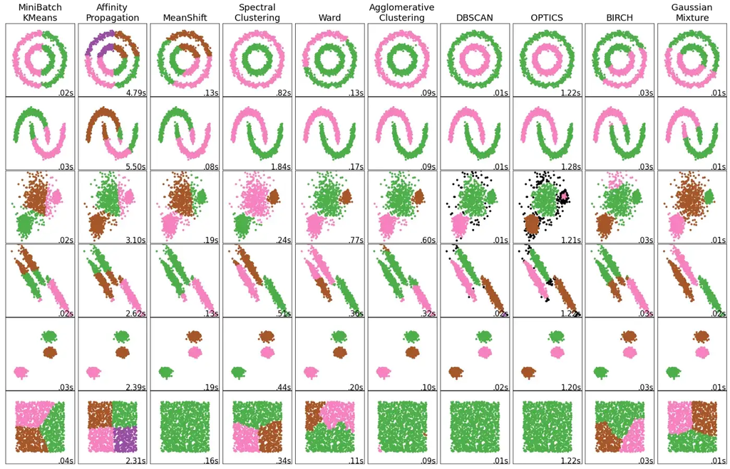

### 6.2

**DBSCAN** estimates the density by counting the number of points in a fixed-radius neighborhood or ɛ and deem that two points are connected only if they lie within each other’s neighborhood. So this algorithm uses two parameters such as ɛ and MinPts. ɛ denotes the Eps-neighborhood of a point and MinPts denotes the minimum points in an Eps neighborhood. So ɛ and MinPts are parameters which are specified by the user

There are a few key points to keep in mind:

Core point: as the core point is taken that particular point which In Eps — neighborhood, has greater value than a precise number of points that is MinPts.

Border Point: as the border point is taken that particular point which In Eps — neighborhood, has less value than a precise number of points that is MinPts.

Noise Point: A point that does not come under in core or border is said to be a noise point.

- Advantage
  - DBSCAN can find arbitrary shaped clusters using MinPts parameters
  - The order of the point in the database is insensitive
  - Handle noise and outliers
- Disadvantage
  - Can not perform well with large differences in densities
  - Not suitable when various density involve

**OPTICS** works like an extension of DBSCAN. The only difference is that it does not assign cluster memberships but stores the order in which the points are processed. So for each object stores: Core distance and Reachability distance. Order Seeds is called the record which constructs the output order.

Core Distance: The minimum value of ɛ which is present in the ɛ-neighborhood of a P is a core distance. Of course, it’s needed to hold the minimum MinPts objects.

Reachability Distance: Reachability distance between p and q is defined as the least radius value that formulates p density reachable from q.

# 7 PCA & LDA

PCA finds directions of maximum variance regardless of class labels while LDA finds directions of maximum class separability. The PC1 the first principal component formed by PCA will account for maximum variation in the data.PC2 does the second-best job in capturing maximum variation and so on. The LD1 the first new axes created by Linear Discriminant Analysis will account for capturing most variation between the groups or categories and then comes LD2 and so on.

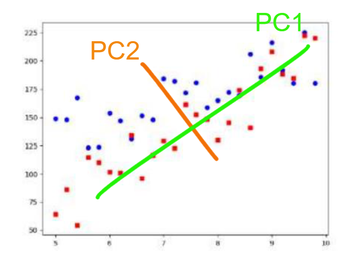

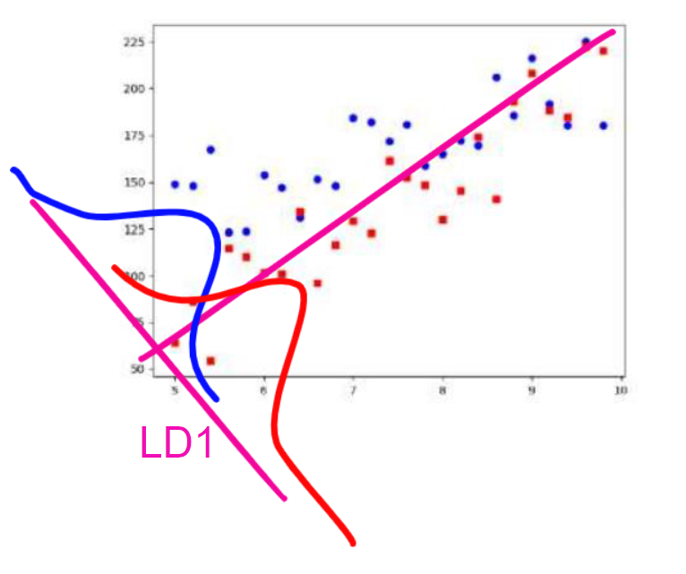